# 10 Discrete IVs and Other

Colin Kuehl

July 21, 2026

## Set-Up

Packages

```r
library(foreign)
library(ggcorrplot)
library(tidyverse)
library(stargazer)
library(modelsummary)
```

Set your working directory and load the height wage data(HeightWage_MenWomenUS_HW.csv).

```r
setwd("~/Dropbox/POLS 641/CMU Su26/cmucourse26/ClassCode/Day 10")
hw <- read.csv("HeightWage_MenWomenUS_HW.csv")
```

## Exploring Wage

Explore the data, we are mostly interested in wage:

```r
summary(hw$wage96)
```

```
##     Min.  1st Qu.   Median     Mean  3rd Qu.     Max.      NAs
##    0.000    6.743   10.783   14.177   16.213 1533.333     5756
```

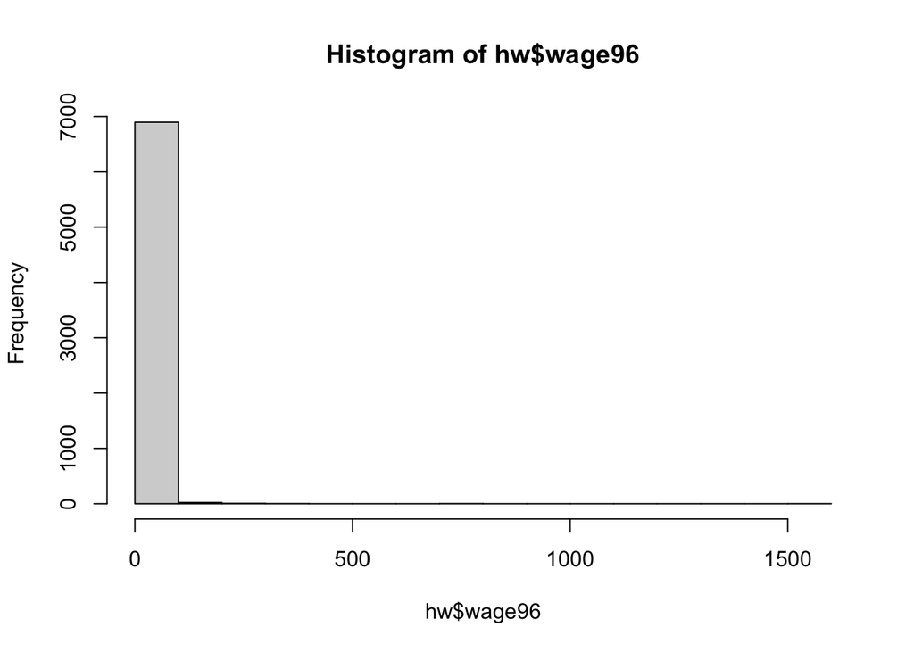

```r
hist(hw$wage96)
```

```r
summary(lm(wage96 ~ esteem80, data=hw))
```

```
##
## Call:
## lm(formula = wage96 ~ esteem80, data = hw)
##
## Residuals:
##     Min      1Q  Median      3Q     Max
##  -17.59   -7.23   -3.17    2.09 1518.09
##
## Coefficients:
##             Estimate Std. Error t value Pr(>|t|)
## (Intercept)  -4.3081     2.8568  -1.508    0.132
## esteem80      0.7821     0.1199   6.524 7.35e-11 ***
## ---
## Signif. codes:  0 '***' 0.001 '**' 0.01 '*' 0.05 '.' 0.1 ' ' 1
##
## Residual standard error: 27.58 on 6719 degrees of freedom
##   (5965 observations deleted due to missingness)
## Multiple R-squared:  0.006295,   Adjusted R-squared:  0.006147
## F-statistic: 42.56 on 1 and 6719 DF,  p-value: 7.348e-11
```

Using just continuous variables, create a multivariate model predicting wage. Practice our interpretation.

## Dummy Variables

Can add to our multivariate regression

```r
table(hw$white)
```

```
##
##    0    1
## 5176 7510
```

```r
table(hw$male)
```

```
##
##    0    1
## 6283 6403
```

```r
ck1a <- (lm(wage96~male, data=hw))#Tells us average for males and non-males
summary(ck1a)
```

```
##
## Call:
## lm(formula = wage96 ~ male, data = hw)
##
## Residuals:
##     Min      1Q  Median      3Q     Max
##  -14.89   -7.20   -3.36    2.01 1519.96
##
## Coefficients:
##             Estimate Std. Error t value Pr(>|t|)
## (Intercept)  13.3761     0.4781  27.975   <2e-16 ***
## male          1.5186     0.6584   2.307   0.0211 *
## ---
## Signif. codes:  0 '***' 0.001 '**' 0.01 '*' 0.05 '.' 0.1 ' ' 1
##
## Residual standard error: 27.36 on 6928 degrees of freedom
##   (5756 observations deleted due to missingness)
## Multiple R-squared:  0.0007673,  Adjusted R-squared:  0.0006231
## F-statistic:  5.32 on 1 and 6928 DF,  p-value: 0.02111
```

```r
hw %>% group_by(male) %>% summarise(mean=mean(wage96, na.rm=T))
```

```
## # A tibble: 2 × 2
##    male  mean
##   <int> <dbl>
## 1     0  13.4
## 2     1  14.9
```

```r
13.37+1.51
```

```
## [1] 14.88
```

```r
t.test(hw$wage96[hw$male==1], hw$wage96[hw$male==0], var.equal = FALSE)
```

```
##
##  Welch Two Sample t-test
##
## data:  hw$wage96[hw$male == 1] and hw$wage96[hw$male == 0]
## t = 2.2344, df = 4778, p-value = 0.02551
## alternative hypothesis: true difference in means is not equal to 0
## 95 percent confidence interval:
##  0.1861617 2.8510406
## sample estimates:
## mean of x mean of y
##  14.89472  13.37612
```

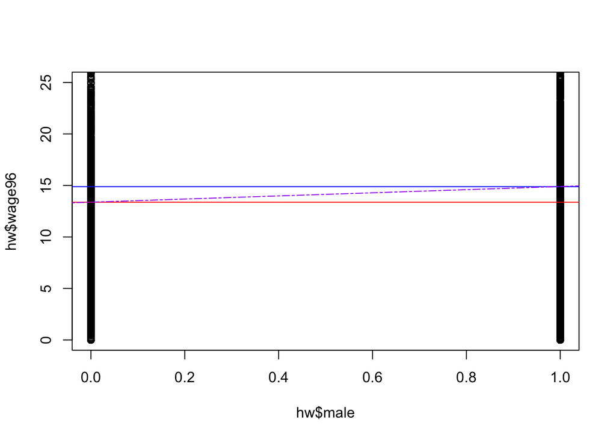

```r
plot(hw$male,hw$wage96, ylim=c(0,25)) #Really zooming in. Black lines are just a bunch of dots
abline(h=13.37, col="red")
abline(h=13.37+1.51, col="blue")
abline(abline(ck1a, lty=6, col="purple"))
```

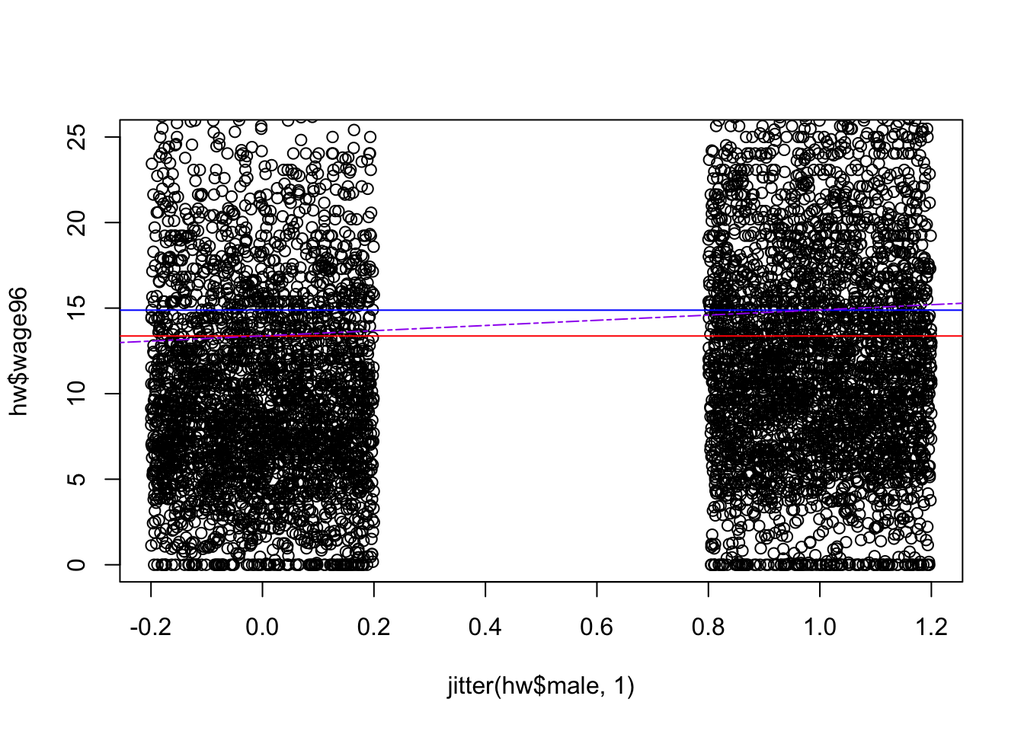

```r
plot(hw$wage96~jitter(hw$male, 1), ylim=c(0,25)) #jitter will spread out your data a bit. in some cases with super large N I will take a random sample to get a better feel for the data.
abline(h=13.37, col="red")
abline(h=13.37+1.51, col="blue")
abline(abline(ck1a, lty=6, col="purple"))
```

Indicate dummy on Multivariate Regression plot

```r
ck3 <- lm(wage96~  age + male, data=hw) #Shows differences between males and females
summary(ck3)
```

```
##
## Call:
## lm(formula = wage96 ~ age + male, data = hw)
##
## Residuals:
##     Min      1Q  Median      3Q     Max
##  -15.18   -7.18   -3.38    2.02 1520.29
##
## Coefficients:
##             Estimate Std. Error t value Pr(>|t|)
## (Intercept) 11.40502    5.34835   2.132   0.0330 *
## age          0.05299    0.15280   0.347   0.7288
## male         1.70840    0.68715   2.486   0.0129 *
## ---
## Signif. codes:  0 '***' 0.001 '**' 0.01 '*' 0.05 '.' 0.1 ' ' 1
##
## Residual standard error: 27.82 on 6570 degrees of freedom
##   (6113 observations deleted due to missingness)
## Multiple R-squared:  0.0009517,  Adjusted R-squared:  0.0006476
## F-statistic: 3.129 on 2 and 6570 DF,  p-value: 0.04381
```

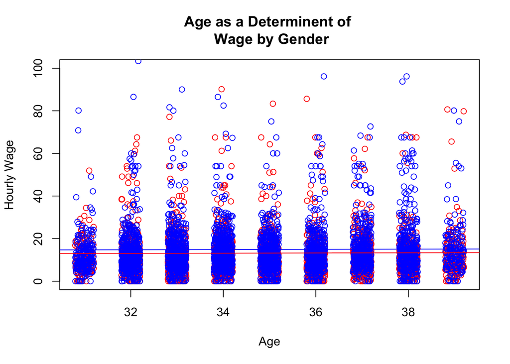

```r
plot(jitter(hw$age[hw$male==0]),(hw$wage96[hw$male==0]), col="red", pch=1, xlab="Age", ylab="Hourly Wage", main="Age as a Determinent of \n Wage by Gender", ylim=c(0,100)) #plots female  note: \n creats new line
#Shorten ylim to show difference
points(jitter(hw$age[hw$male==1]), hw$wage96[hw$male==1], col="blue", pch=1) #plots male
legend(50,90, legend=c("Female", "Male"), col=c("red", "blue"), pch=c(1, 16), bty="n")
abline(a=11.405, b=.052, col="red") # intercept and slope from above
abline(a=(11.405+1.708), b=.052, col="blue")
```

## More Multivariate Models

```r
ck2 <- lm(wage96~ male+ height85 + siblings + age, data=hw) #Shows differences between males and females
summary(ck2)
```

```
##
## Call:
## lm(formula = wage96 ~ male + height85 + siblings + age, data = hw)
##
## Residuals:
##     Min      1Q  Median      3Q     Max
##  -18.65   -7.07   -3.18    2.16 1518.22
##
## Coefficients:
##             Estimate Std. Error t value Pr(>|t|)
## (Intercept) -8.13697    9.57694  -0.850  0.39556
## male        -0.27730    1.00588  -0.276  0.78281
## height85     0.32013    0.12279   2.607  0.00915 **
## siblings    -0.68540    0.13512  -5.072 4.04e-07 ***
## age          0.09949    0.15667   0.635  0.52546
## ---
## Signif. codes:  0 '***' 0.001 '**' 0.01 '*' 0.05 '.' 0.1 ' ' 1
##
## Residual standard error: 28.06 on 6377 degrees of freedom
##   (6304 observations deleted due to missingness)
## Multiple R-squared:  0.006359,   Adjusted R-squared:  0.005736
## F-statistic:  10.2 on 4 and 6377 DF,  p-value: 3.116e-08
```

```r
ck2a <- lm(wage96~ male+ height85 + siblings + age, data=hw)
summary(ck2a)
```

```
##
## Call:
## lm(formula = wage96 ~ male + height85 + siblings + age, data = hw)
##
## Residuals:
##     Min      1Q  Median      3Q     Max
##  -18.65   -7.07   -3.18    2.16 1518.22
##
## Coefficients:
##             Estimate Std. Error t value Pr(>|t|)
## (Intercept) -8.13697    9.57694  -0.850  0.39556
## male        -0.27730    1.00588  -0.276  0.78281
## height85     0.32013    0.12279   2.607  0.00915 **
## siblings    -0.68540    0.13512  -5.072 4.04e-07 ***
## age          0.09949    0.15667   0.635  0.52546
## ---
## Signif. codes:  0 '***' 0.001 '**' 0.01 '*' 0.05 '.' 0.1 ' ' 1
##
## Residual standard error: 28.06 on 6377 degrees of freedom
##   (6304 observations deleted due to missingness)
## Multiple R-squared:  0.006359,   Adjusted R-squared:  0.005736
## F-statistic:  10.2 on 4 and 6377 DF,  p-value: 3.116e-08
```

Question: Does participation in high school athletics(athlets) have an affect on wage?

```r
summary(lm(wage96~athlets, data=hw))
```

```
##
## Call:
## lm(formula = wage96 ~ athlets, data = hw)
##
## Residuals:
##     Min      1Q  Median      3Q     Max
##  -16.42   -7.19   -3.19    2.18 1516.92
##
## Coefficients:
##             Estimate Std. Error t value Pr(>|t|)
## (Intercept)  12.6851     0.4391  28.889  < 2e-16 ***
## athlets       3.7300     0.6795   5.489 4.18e-08 ***
## ---
## Signif. codes:  0 '***' 0.001 '**' 0.01 '*' 0.05 '.' 0.1 ' ' 1
##
## Residual standard error: 27.58 on 6773 degrees of freedom
##   (5911 observations deleted due to missingness)
## Multiple R-squared:  0.004429,   Adjusted R-squared:  0.004282
## F-statistic: 30.13 on 1 and 6773 DF,  p-value: 4.184e-08
```

```r
summary(lm(wage96~athlets+hgc96+siblings+height85+white+clubnum, data=hw))
```

```
##
## Call:
## lm(formula = wage96 ~ athlets + hgc96 + siblings + height85 +
##     white + clubnum, data = hw)
##
## Residuals:
##     Min      1Q  Median      3Q     Max
##  -27.39   -6.59   -2.72    2.08 1517.47
##
## Coefficients:
##              Estimate Std. Error t value Pr(>|t|)
## (Intercept) -19.64573    6.01271  -3.267  0.00109 **
## athlets       1.42530    0.72873   1.956  0.05052 .
## hgc96         1.52887    0.15831   9.657  < 2e-16 ***
## siblings     -0.26847    0.13814  -1.943  0.05200 .
## height85      0.20124    0.08462   2.378  0.01743 *
## white         1.28600    0.71669   1.794  0.07280 .
## clubnum      -0.32490    0.36239  -0.897  0.37000
## ---
## Signif. codes:  0 '***' 0.001 '**' 0.01 '*' 0.05 '.' 0.1 ' ' 1
##
## Residual standard error: 27.53 on 6623 degrees of freedom
##   (6056 observations deleted due to missingness)
## Multiple R-squared:  0.02465,    Adjusted R-squared:  0.02376
## F-statistic: 27.89 on 6 and 6623 DF,  p-value: < 2.2e-16
```